# a3_task3_jordan_davis

Jordan Marisa Davis

10/30/2020

## Read in data and clean it up

The “urchins.csv” file was read into R using the “here” package. The data was cleaned using the janitor package so text appears in lower_snake_case.

```r
urchins <- read.csv(here("data", "urchins.csv")) %>%
  clean_names()
```

## Section 1

### Exploratory data visualization

Exploratory histograms were created to understand the number of urchins and size in the data.

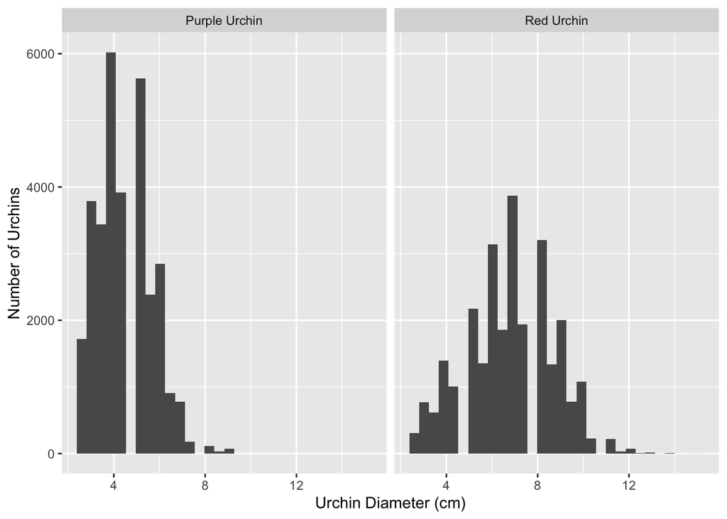

```r
ggplot(data = urchins, aes(x = size)) +
  geom_histogram()+
  facet_wrap(~common_name) +
  labs(x = "Urchin Diameter (cm)",
       y = "Number of Urchins")
```

[figure not shown]

```r
ggplot(data = urchins, aes(x = common_name, y = size)) +
  geom_boxplot()+
  labs(x = "Urchin Diameter (cm)",
       y = "Number of Urchins")
```

### Descriptive statistics table

A summary table was created to explore the mean, median, standard deviation, and sample size of the purple and red urchins.

```r
urchin_stats <- urchins %>%
  group_by(common_name) %>%
  summarize(mean_urchin = mean(size),
            median_urchin = median(size),
            sd_urchin = sd(size),
            n = n())
urchin_stats
```

```
## # A tibble: 2 x 5
##   common_name   mean_urchin median_urchin sd_urchin     n
##   <chr>               <dbl>         <dbl>     <dbl> <int>
## 1 Purple Urchin        4.47           4.5      1.18 31805
## 2 Red Urchin           6.78           7        1.89 27408
```

### Section 1: Summary

The mean and median calculated in the summary table suggest that the purple urchin is smaller in size. The mean of the purple urchins was about 2.31 cm smaller than the red urchin; however, it should be noted that the sample size (n) of the purple urchins was about 4000 greater than the red urchins. Taking sample size into account, the actual percent differne is 0.011 percent.

```r
red_urch_diff = 6.776489/27408
purpl_urch_diff = 4.469797/31805
red_purp_diff = (red_urch_diff - purpl_urch_diff) * 100
red_purp_diff
```

```
## [1] 0.01067074
```

## Section 2

### Purple Urchins Data

Here, I filter the purple urchins data. I re-format the date so there is a column specifically for year, and add more detail to the site names.

```r
urchins_date <- urchins %>%
  mutate(date = mdy(date))

class(urchins$date)
```

```
## [1] "character"
```

```r
purple_urchins <- urchins_date %>%
  filter(common_name %in% c("Purple Urchin")) %>%
  mutate(Date = ymd(date)) %>%
  mutate(Year = year(Date)) %>%
  mutate(site_full = case_when(
         site == "NAPL" ~ "Naples Reef",
         site == "AQUE" ~ "Arroyo Quemado Reef",
         site == "CARP" ~ "Carpinteria Reef",
         site == "MOHK" ~ "Mohawk Reef",
         site == "IVEE" ~ "Isla Vista"
  ))
```

### Summary

Here I summarize the purple urchins data to calculate a count of each site by year.

```r
p_urchins_sum <- purple_urchins%>%
 group_by(site_full, Year) %>%
  summarize(count = n())
```

### Exploratory graph

Here I create an exploratory graph to help visualize the counts of purple urchins recorded at each site over time for the years.

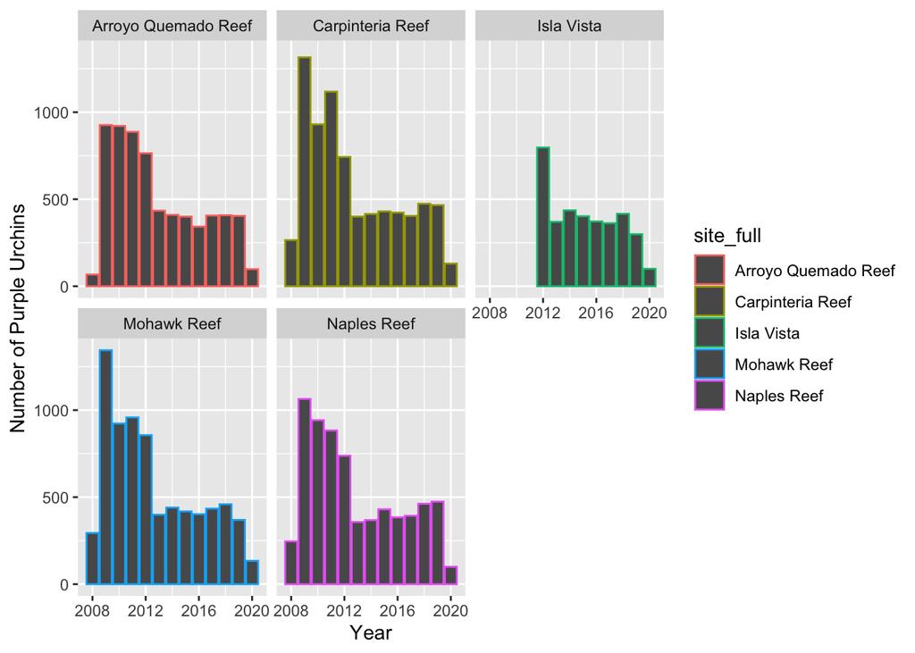

```r
ggplot(data = p_urchins_sum, aes(x = Year, y = count))+
  geom_col(aes(color = site_full)) +
  facet_wrap(~site_full)+
  labs(x = "Year",
       y = "Number of Purple Urchins")
```